# 交友軟體使用者之工作型態分析

2017/6/15

## 數據形態：

```
##         job                company
## 1       job                company
## 2    工程師               科技公司
## 3    工程師               軟體公司
## 4      學生                   大仁
## 5      學生
## 6  行銷業務 妙華如發西套裝量身訂製
## 7                           創業中
## 8  陪老人玩               公益團體
## 9      工讀             唐朝麻辣燙
## 10     汪汪               幸福企業
```

## 數據攫取原理：

我先將所有資料以不區分字詞的方式從大到小排列，並從中抓取出現超過十次的字詞作為分群的底線，我從這些出現超過十次的字詞做分類分群，得出以下的結果**（職業類別&行業類別）**。

有些字詞會是重複並且相關的，那我只需要讀取關鍵字即可抓出總次數，例如:”設計”出現88次，”設計師”出現 250次，我只需要讀取”設計”即可抓出88+250=338次。(只要是相關的就會歸類在一群)

```
##        job  var
## 1     學生 2590
## 2   工程師 1518
## 3     業務  806
## 4           700
## 5       無  502
## 6     員工  395
## 7     經理  262
## 8  Student  260
## 9   設計師  250
## 10  研究生  238
```

## job欄位分析原理：

**job**我將此欄位定義為職業類別，此類別表示個人擔任之工作或職務，在一間公司中，是由各個大大小小的螺絲釘所組成的，我將類似以及同性質的工作類型區分為一群，以及沒有顯示特別專業只說明職稱的人區分為一類，以此可看出，大約是哪些工作類型的人在使交友軟體。

## 職業類別：個人擔任之工作或職務

##### 1.Boss/共同創辦人/小老闆/負責人/創業家/Co-Founder/CEO/COO/總經理/總監/執行長/Founder/董事長/校長兼撞鐘/CTO

##### 2.Manager/課長/店長/副總/襄理/協理/領班/主任/副理/組長/儲備幹部

##### 3.工程師/Engineer/程式

##### 4.業務/銷售/Sales

##### 5.助理/秘書/行政/會計/採購/特助/客服/編輯/櫃檯/財務/總務

##### 6.設計/美編

##### 7.R&D/研發/RD

##### 8.公關/行銷/企劃

##### 9.顧問/Consultant

##### 10.技術員/技師/工人/工務/作業員/技術師

##### 11.勞工/員工/專員/服務員/店員/職員/上班族/內勤/正職/行員/人員

##### 12.打雜/實習生/雜工/菜鳥/學徒/外場/內場/門市

##### 13.待業/無

##### 14.管理/倉管/品管

## 長條圖

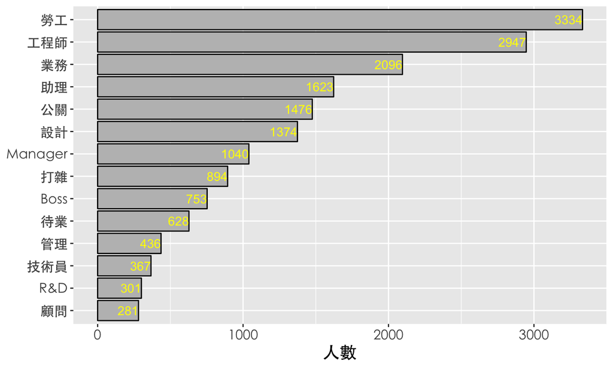

## company欄位分析原理

**company** 我將此欄位定義為行業類別，此類別表示經濟活動部門之種類，我將類似的產業類別區分為一群，以此可看出，大約是哪些產業類別的人在使用Eatgether。

## 行業類別：經濟活動部門之種類

###### 1.學生/大學/NTU/NTHU/台大/研究所/成大/政大/NCTU

###### 2.廣告/設計/出版社/Media

###### 3.服務/飯店/旅行社/旅遊/百貨/麥當勞/服飾/咖啡/新光三越

###### 4.科技/南科/遊戲/網路/軟體/電商/中科/網拍/電腦/資訊

###### 5.教育/補習班/老師/School/補教

###### 6.自由/Freelancer

###### 7.金融/銀行/Bank

###### 8.製造/工廠/傳產/物流/營造/建設/傳統產業/建築/藥廠/房地產/紡織/機械

###### 9.醫院/醫療/診所

###### 10.電子/IT/TSMC/半導體/台積電

###### 11.餐廳/餐飲/食品

###### 12.貿易/外商/日商/美商

###### 13.人壽/富邦/三商美邦/保險

###### 14.公家/公職/政府/公務員

###### 15.替代役/軍/國家/兵

###### 16.事務所/律師/會計師

###### 17.新創/工作室/Soho

## 長條圖

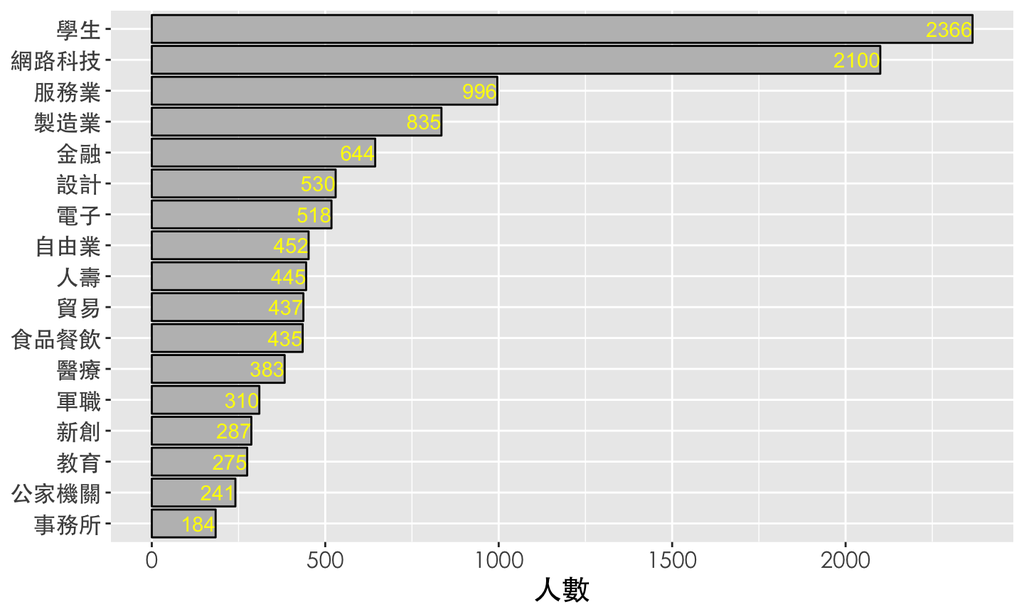